# Analysis of Emergency Visits for Asthma Across California. Uncovering Hidden Predispositions.

Adam Guerra

2023-03-14

# Abstract

How different socioeconomic groups experience the world is an integral part of all aspects of science, and understanding those differences or how to predict them is just as important. In this study I take data found from the OEHAA, clean and select for some key variables that I suspected have to do with asthma hospitalizations. I believe that some communities are predisposed to having more cases than others. Within this study there will be two statistical tests that look at two different categories of community to look for statistical differences, and one that tested predicting the number of asthma hospitalizations using another variable that has correlation. I will highlight assumptions for tests, tests themselves, figures of the data and results, and what the results mean in relation to the real world.

# Introduction

Asthma is a condition that affects roughly 1 in 13 people in the United States. It is a chronic condition that affects the airways to the lungs by causing inflammation which leads to difficulty breathing. There are certain triggers such as pollen, exercise, viral infections, cold air, particulates, etc which increases symptoms and could potentially lead to an asthma attack (NHLBI). The quality of care that people that suffer from asthma receive plays a key role in hospitalization rates. Some groups of people don’t have access or the means to receive these treatments (Homer, et al.). This information led to the question of, are certain communities predisposed to more hospitalizations due to asthma?  
Using demographic data collected by OEHAA (California Office of Environmental Health Hazard Assessment), I am going to look at hospitalization rates caused by asthma in both disadvantaged communities and communities classified as having a predominately white population. This data contains 1000 observations of 41 variables. I will calculate the predominately white communities variable using the ethnicity data provided in the data and select the census tracts that have more than 50% of the population listed as white. As for the census tracts labeled as disadvantaged communities, this is determined by SB 535 standards that incorporate geographic, socioeconomic, public health, and environmental hazard criteria. Each of these will be compared against their respective counter part (i.e disadvantaged vs non-disadvantaged). I hypothesize that in each group there will be a significant difference between the means. This will give insight to if there are communities that are predisposed to hospitalizations due to asthma. After this I will be looking at poverty and education levels as predictors of the hospitalization rates in different communities, to see if a linear regression can accurately predict if a community will have high hospitalization rates for asthma. For this final regression, I hypothesize that they will be significant predictors of asthma hospitalizations.

# Exploratory Data Analysis

### Import and Clean Data

The first step in my analysis was to import the data and omit any NA values. Then I proceeded to select the columns I needed for analysis, cleaned the names, added new columns I needed, and ensured categorical variables are classified as factors with two levels.

### Visualize Data

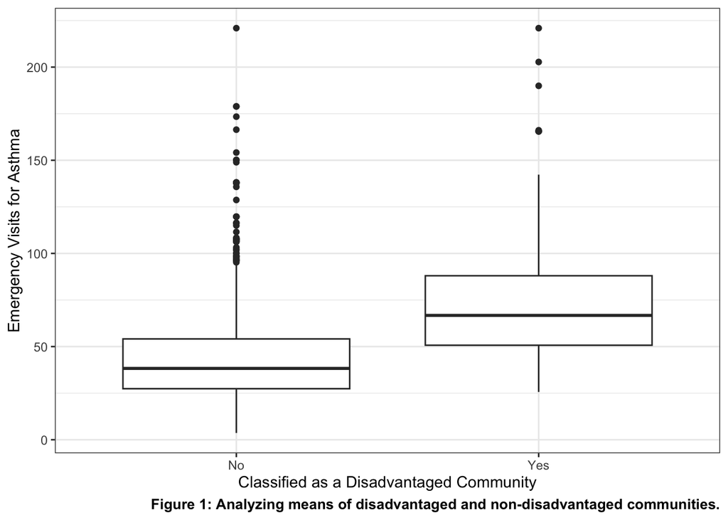

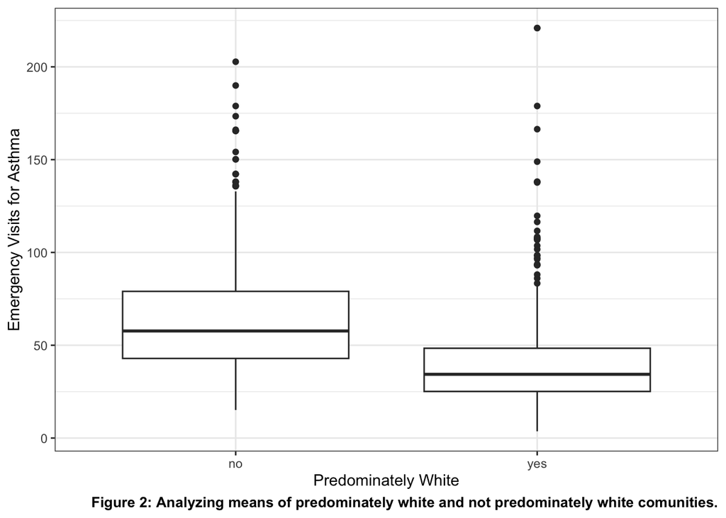

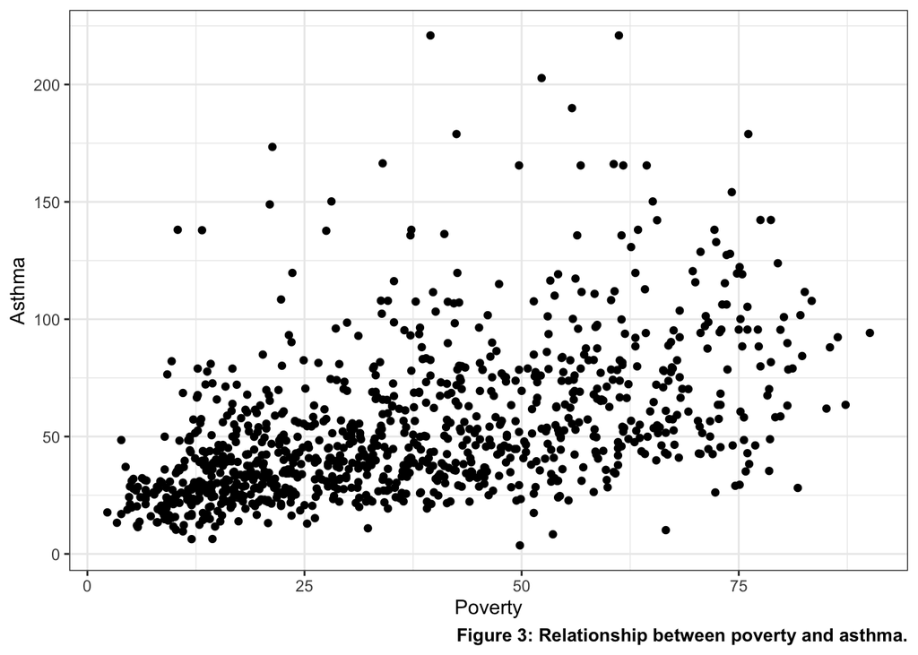

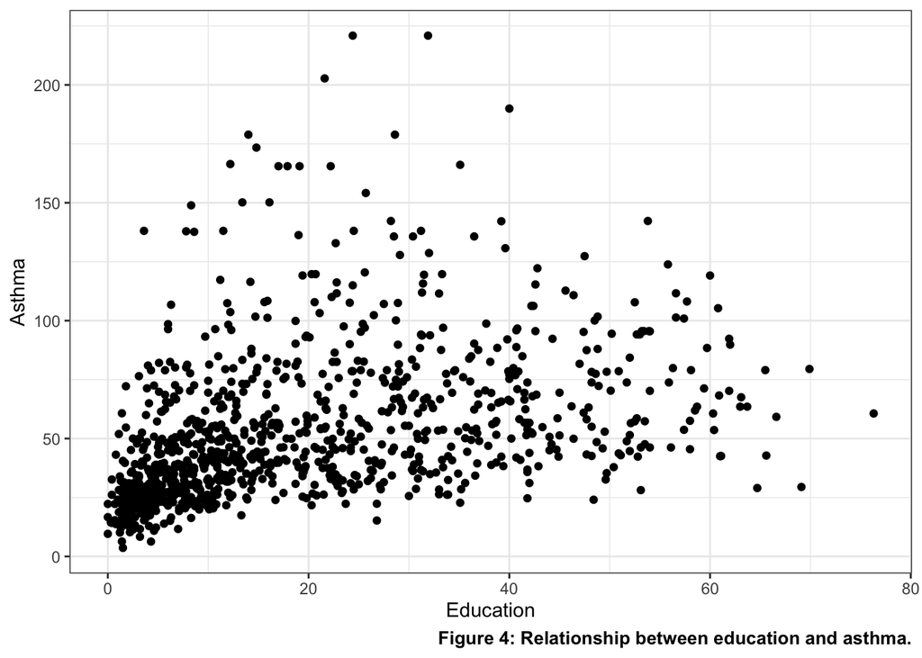

### Normality Test for Response Variable

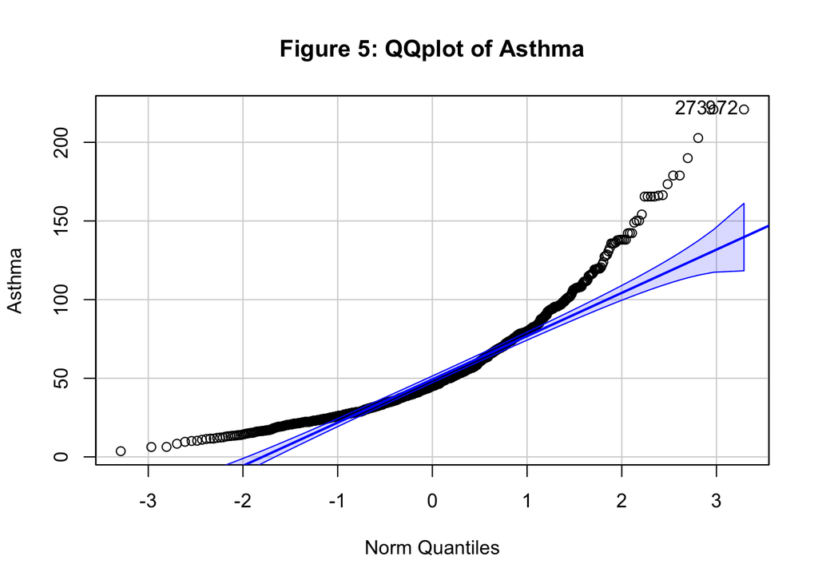

```
## [1] 273 972
```

### Transform Repsonse Variable and Retest Normaility

Since this is the case I performed a log transformation on the asthma data and retest normality, shown in figure 6. After this transformation the data passes the assumption of normality.

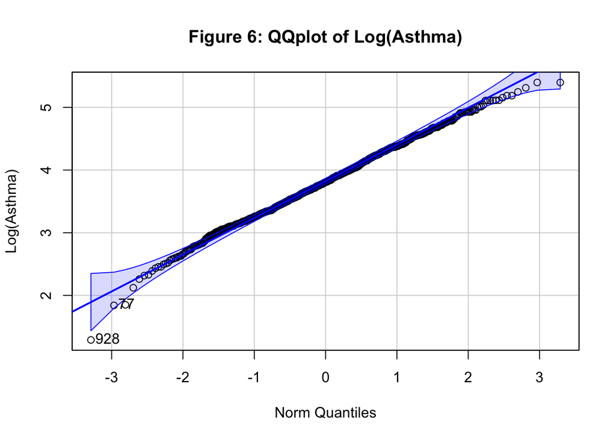

```
## [1] 928  77
```

### Co-Linearity Check

Lastly, I needed to check for co linearity between my two potential predictor variable, and after running a pairs panels, figure 7, to look at linearity and correlation it was clear that education and poverty were correlated. This means that I removing one of them from my linear model. Since poverty has a correlation of 0.54 and education has a correlation of 0.48, I am choosing to remove education. I am changing my hypothesis to be: poverty will be a significant predictor of log(asthma).

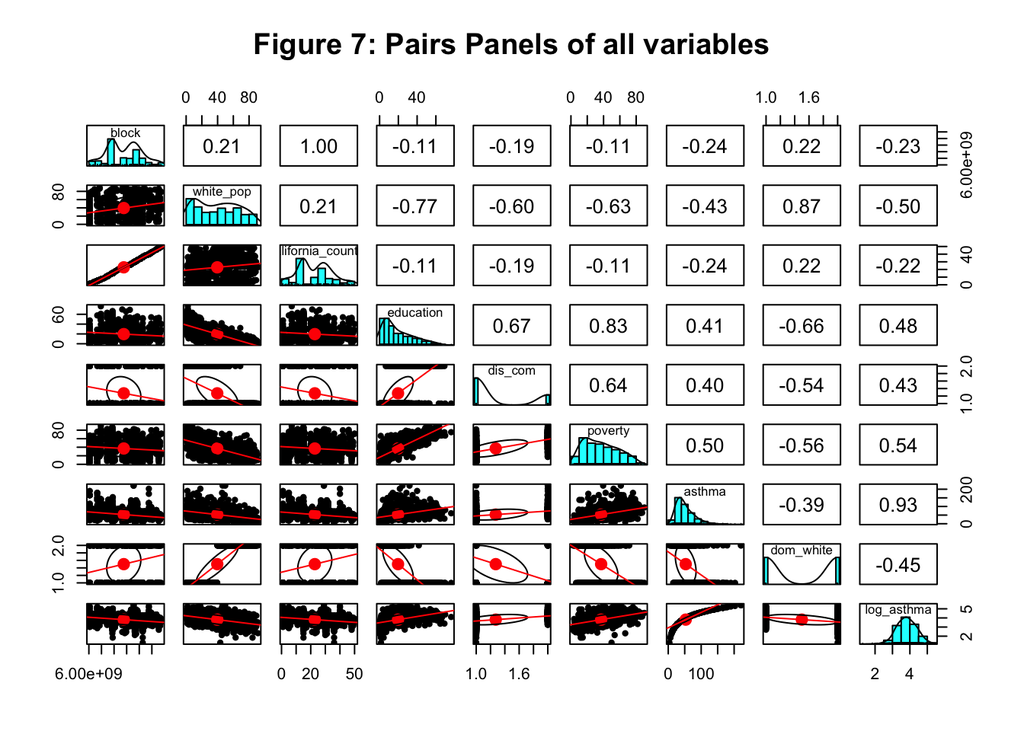

# Statistical Methods

### Are the mean log number of hospital visits due to asthma the same in communities labeled disadvantaged vs those that are not?

For the first test of means I will be using a Welch’s two sample t test. When comparing means of two samples that are independent but variances are not equal, this is the non-parametric test that should be run. Since the response variable is normally distributed and it is a random sample we can run this. Below are the null and alternate hypotheses:  
$H_0: \mu_{disadvantaged} = \mu_{non-disadvantaged}$  
$H_A: \mu_{disadvantaged} \ne \mu_{non-disadvantaged}$  
I set up two objects that give the log(asthma) data for each grouping. Then I ran a Levene’s Test to check equality of variances, an assumption for two sample t tests. Since the p-value of 6.9e-6 is less than 0.05, we reject the null hypothesis of the Levene’s Test and the variances are not equal. As I mentioned above this is why I am running a Welch’s t test. The t test itself will give a p value that will either be above or below 0.05. In the case it is below, I can reject the null hypothesis I stated earlier. If it is higher then I fail to reject the null. Then since normality and random assumptions have already been met I ran the test and recorded the results (see results section for findings).

```
## Levene's Test for Homogeneity of Variance (center = median)
##        Df F value    Pr(>F)
## group   1  20.436 6.905e-06 ***
##       998
## ---
## Signif. codes:  0 '***' 0.001 '**' 0.01 '*' 0.05 '.' 0.1 ' ' 1
```

```
##
##  Welch Two Sample t-test
##
## data:  yes_dis$log_asthma and no_dis$log_asthma
## t = 17.385, df = 657.86, p-value < 2.2e-16
## alternative hypothesis: true difference in means is not equal to 0
## 95 percent confidence interval:
##  0.4892342 0.6138244
## sample estimates:
## mean of x mean of y
##  4.214333  3.662803
```

### Are the mean log number of hospital visits due to asthma the same in communities classified as predominatly white vs those that aren’t?

For the second test of means I will be using a Welch’s two sample t test. When comparing means of two samples that are independent but variances are not equal, this is the non-parametric test that should be run. Since the response variable is normally distributed and it is a random sample we can run this. Below are the null and alternate hypotheses:  
$H_0: \mu_{white} = \mu_{non-white}$  
$H_A: \mu_{white} \neq \mu_{non-white}$  
I set up two objects that give the log(asthma) data for each grouping. Then I ran a Levene’s Test to check equality of variances, an assumption for two sample t tests. Since the p-value of 0.04 is less than 0.05, we reject the null hypothesis of the Levene’s Test and the variances are not equal. As I mentioned above this is why I am running a Welch’s t test. The t test itself will give a p value that will either be above or below 0.05. In the case it is below, I can reject the null hypothesis I stated earlier. If it is higher then I fail to reject the null. Then since normality and random assumptions have already been met I ran the test and recorded the results (see results section for findings).

```
## Levene's Test for Homogeneity of Variance (center = median)
##        Df F value  Pr(>F)
## group   1  4.0801 0.04366 *
##       998
## ---
## Signif. codes:  0 '***' 0.001 '**' 0.01 '*' 0.05 '.' 0.1 ' ' 1
```

```
##
##  Welch Two Sample t-test
##
## data:  yes_white$log_asthma and no_white$log_asthma
## t = -16.023, df = 974.51, p-value < 2.2e-16
## alternative hypothesis: true difference in means is not equal to 0
## 95 percent confidence interval:
##  -0.5753631 -0.4498039
## sample estimates:
## mean of x mean of y
##  3.557079  4.069663
```

### Is poverty a significant predictor of the log of hospitial visits due to asthma for a community?

For my third test I am performing a linear regression using log(asthma) as the response variable and poverty as the prediction variable. A linear regression checks if a, x, numeric variable is a good predictor of a, y, response variable. It uses a simple linear equation most people are used to $y = \beta_1 x + \beta_0$. The linear model will provide a p value greater than or less than 0.05, same as the t test previously used, and the same principle applies with rejecting or failing to reject the null hypothesis. For this test my hypothesis is:  
$H_0: \beta = 0$  
$H_A: \beta \neq 0$  
where if $\beta = 0$, this means the model is not a significant predictor of the response variable. There is also an $r^2$ value provided by the linear model which will be between 0 and 1. This represents the decimal percent of the variance explained by the linear model. In the code below I created the linear model using the aforementioned predictor and response variables. Next, I had to test normality of the residuals and variance of the residuals. I did this by plotting the linear model and assessing the residuals vs fitted and QQ plots. Both showed that the assumptions were met. The output of the linear model is shown here, but results of the test are discussed in the results section.

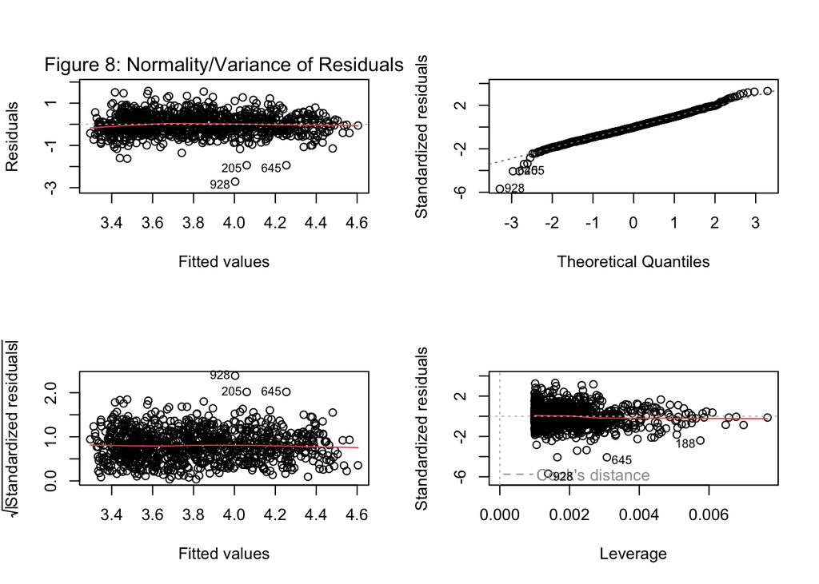

```
##
## Call:
## lm(formula = log_asthma ~ poverty, data = asthma_data)
##
## Residuals:
##      Min       1Q   Median       3Q      Max
## -2.71428 -0.31213 -0.01703  0.30727  1.57697
##
## Coefficients:
##              Estimate Std. Error t value Pr(>|t|)
## (Intercept) 3.2610778  0.0311364  104.73   <2e-16 ***
## poverty     0.0149084  0.0007351   20.28   <2e-16 ***
## ---
## Signif. codes:  0 '***' 0.001 '**' 0.01 '*' 0.05 '.' 0.1 ' ' 1
##
## Residual standard error: 0.4773 on 998 degrees of freedom
## Multiple R-squared:  0.2918, Adjusted R-squared:  0.2911
## F-statistic: 411.3 on 1 and 998 DF,  p-value: < 2.2e-16
```

# Results

### Test 1: Disadvantaged vs Non-disadvantaged, Comparing Means Using Welch’s T-Test.

I found a significant difference in the log mean number of visits to hospitals between disadvantaged and non-disadvantaged communities. The result from Welch’s t test was a p-value of 2.2e-16, which is significantly less than 0.05. This confirms that we can reject the null hypothesis that there is no difference in the means between the two groups, and we divert to the alternate hypothesis that there is a significant difference in the means. Applying this to the question I was trying to answer, communities labeled disadvantaged have significantly more hospital visits due to asthma. This can visually be seen in figure 1.

### Test 2: Pre-dominately White vs Non-White, Comparing Means Using Welch’s T-Test.

In the second comparison of means I found a significant difference in the log mean number of visits to hospitals due to asthma between predominately white and non-white communities. The p-value from the Welch t-test was 2.2e-16 which is less than 0.05, meaning we again reject the null hypothesis and divert to the alternate of there being a significant difference in the means. In the context of the question I am trying to answer, there are significantly more hospital visits due to asthma in non-white communities. This is seen in figure 2.

### Test 3: Poverty as a Predictor of log hospital asthma visits.

In the final test of my study, I found that poverty was a significant predictor of log hospital visits due to asthma. The summary of the linear model resulted in a p-value of 2.2e-16, which again is less than 0.05 so we can reject the null hypothesis and use the alternate hypothesis that poverty is a significant predictor of log(asthma). The summary also shows a multiple $r^2$ value of 0.2918, which in the context of the linear model means that 29.18% of variance in log(asthma) is accounted for by poverty. Although poverty can predict log(asthma), it is not the best predictor since it only accounts for 29.18% of the variance, a good predictor should be upwards of 60%. Below, in figure 9, I trained the model using 90% of the data and tested it with the remaining 10%.

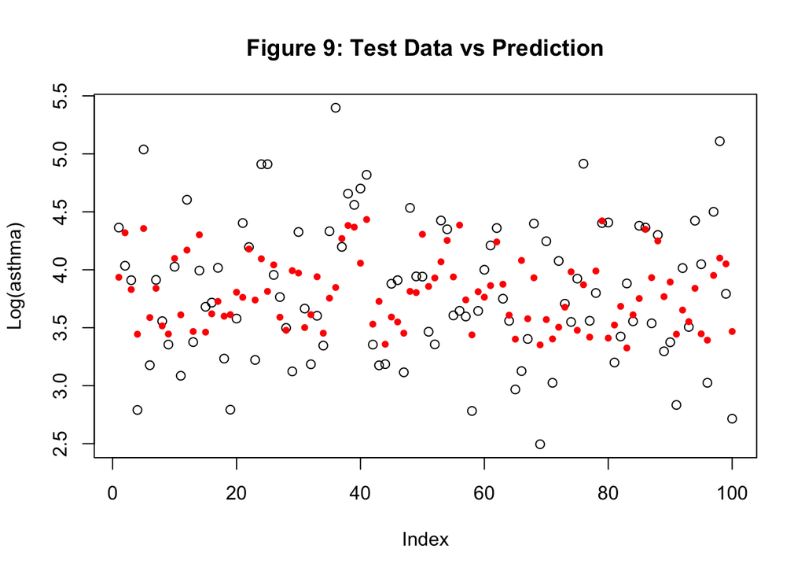

# Discussion

The results of my study showed how there are clearly predispositions for hospital visits due to asthma for certain communities. I highlighted two of those in my first two tests where both disadvantaged and non-predominately white areas were unequally burdened. This likely has to do with how quality of ambulatory care and preventative therapies plays a large role in determining hospitalization for asthma. Many communities that don’t have the same access to different resources like money or treatments won’t be able to reduce their asthma hospitalizations the same way others that have those luxuries will. Disadvantaged and non-white communities are just two examples of those that may lack access. There are clearly many factors at play and a long history for why communities, like ones that are non-white, are at a predisposition for asthma hospitalizations. A history that includes racism and unequal opportunity. One of the largest is poverty, which after using a linear regression was found to be a significant predictor of the log of asthma hospitalizations. This may not sound exactly useful but by doing the inverse of a natural log I can arrive back at the number of asthma hospital visits. It is likely that adding other parameters alongside poverty, such as vicinity to pollution sources would increase $r^2$ value (it is important to keep in mind many of the variable that result in an area being predisposed likely all have to do with one another. An example of this is: lower education level likely leads to lower economic status, which likely leads to living in a poorer area and less access or ability to afford high end healthcare, which leads to worse living conditions, which leads to worse health). This is one way I could have improve my linear model/study and reduce its limitations. The most important take away from the study is that there needs to be something done to create equity across communities. There are predispositions that aren’t being addressed once brought to light through studies like this one, and it is unfair to be aware of the problem but leave many people suffering.

# References

1. R Core Team (2022). R: A language and environment for statistical computing. R Foundation for Statistical Computing, Vienna, Austria. URL https://www.R-project.org/.
2. Wickham H, Hester J, Bryan J (2022). *readr: Read Rectangular Text Data*. R package version 2.1.3, https://CRAN.R-project.org/package=readr.
3. Müller K (2020). *here: A Simpler Way to Find Your Files*. R package version 1.0.1, https://CRAN.R-project.org/package=here.
4. H. Wickham. ggplot2: Elegant Graphics for Data Analysis. Springer-Verlag New York, 2016.
5. John Fox and Sanford Weisberg (2019). An {R} Companion to Applied Regression, Third Edition. Thousand Oaks CA: Sage. URL: https://socialsciences.mcmaster.ca/jfox/Books/Companion/
6. Wickham H, Averick M, Bryan J, Chang W, McGowan LD, François R, Grolemund G, Hayes A, Henry L, Hester J, Kuhn M, Pedersen TL, Miller E, Bache SM, Müller K, Ooms J, Robinson D, Seidel DP, Spinu V, Takahashi K, Vaughan D, Wilke C, Woo K, Yutani H (2019). “Welcome to the tidyverse.” *Journal of Open Source Software*, *4*(43), 1686. doi:10.21105/joss.01686 https://doi.org/10.21105/joss.01686.
7. Revelle, W. (2022) psych: Procedures for Personality and Psychological Research, Northwestern University, Evanston, Illinois, USA, https://CRAN.R-project.org/package=psych Version = 2.2.9.
8. Yihui Xie (2023). knitr: A General-Purpose Package for Dynamic Report Generation in R. R package version 1.42.
9. Firke S (2021). *janitor: Simple Tools for Examining and Cleaning Dirty Data*. R package version 2.1.0, https://CRAN.R-project.org/package=janitor.
10. Wilke C (2020). *cowplot: Streamlined Plot Theme and Plot Annotations for ‘ggplot2’*. R package version 1.1.1, https://CRAN.R-project.org/package=cowplot.
11. “CalEnviroScreen.” Oehha.ca.gov, California Office of Environmental Health Hazard Assesment, Oct. 2021, https://oehha.ca.gov/calenviroscreen/about-calenviroscreen.
12. Homer, Charles J., et al. “Does Quality of Care Affect Rates of Hospitalization for Childhood Asthma?” Pediatrics, vol. 98, no. 1, 1996, pp. 18–23., https://doi.org/10.1542/peds.98.1.18.
13. Siroux, Valérie, et al. “Phenotypic Determinants of Uncontrolled Asthma.” Journal of Allergy and Clinical Immunology, vol. 124, no. 4, 10 Aug. 2009, https://doi.org/10.1016/j.jaci.2009.06.010.
14. “What Is Asthma?” National Heart Lung and Blood Institute, U.S. Department of Health and Human Services, 24 Mar. 2022, https://www.nhlbi.nih.gov/health/asthma.